# Project: Data Preparation and Exploration: IS 6487-090 Fall 2019 Intro to Bus Analytics

Meag Tessmann

9/5/2019

## Project: Data Preparation and Exploration

# Side thing: Tables!

```r
table(iris$Species)
```

```
##
##     setosa versicolor  virginica
##         50         50         50
```

# Back to Data Prep

This project assignment challenges you to take what you observed there–workflow, exploration and visualization strategies, specific code–and apply it to the case from last module, AdviseInvest, for which you developed interview questions and wrote a business problem statement. The business understanding you acquired there will inform the data work you do in this exercise. Your assignment is to download the data, clean it as directed below, and perform some basic data summaries and visualizations. Use your results to answer the quiz questions. Note: You get one try at this quiz.

```r
# Load packages
library(dplyr)
library(tidyverse)
# Import data & familiarize

df <- read.csv("adviseinvest_dirty.csv")
summary(df)
```

```
##     answered          income           female             age
##  Min.   :0.0000   Min.   :-65600   Min.   :0.00000   Min.   :19.00
##  1st Qu.:0.0000   1st Qu.: 13550   1st Qu.:0.00000   1st Qu.:26.00
##  Median :1.0000   Median : 23310   Median :0.00000   Median :32.00
##  Mean   :0.5466   Mean   : 33767   Mean   :0.05423   Mean   :34.77
##  3rd Qu.:1.0000   3rd Qu.: 41690   3rd Qu.:0.00000   3rd Qu.:40.00
##  Max.   :1.0000   Max.   :159450   Max.   :1.00000   Max.   :74.00
##
##       job        num_dependents       rent           own_res
##  Min.   :0.000   Min.   :1.000   Min.   :0.0000   Min.   :0.0000
##  1st Qu.:2.000   1st Qu.:1.000   1st Qu.:0.0000   1st Qu.:0.0000
##  Median :2.000   Median :1.000   Median :0.0000   Median :1.0000
##  Mean   :1.915   Mean   :1.141   Mean   :0.2104   Mean   :0.6811
##  3rd Qu.:2.000   3rd Qu.:1.000   3rd Qu.:0.0000   3rd Qu.:1.0000
##  Max.   :3.000   Max.   :2.000   Max.   :1.0000   Max.   :1.0000
##
##     new_car          chk_acct        sav_acct        num_accts
##  Min.   :0.0000   Min.   :0.000   Min.   :0.0000   Min.   :   0.000
##  1st Qu.:0.0000   1st Qu.:0.000   1st Qu.:0.0000   1st Qu.:   2.000
##  Median :0.0000   Median :1.000   Median :0.0000   Median :   2.000
##  Mean   :0.2408   Mean   :1.469   Mean   :0.9566   Mean   :   2.458
##  3rd Qu.:0.0000   3rd Qu.:3.000   3rd Qu.:2.0000   3rd Qu.:   3.000
##  Max.   :1.0000   Max.   :3.000   Max.   :4.0000   Max.   :3345.000
##  NA's   :2
##      mobile           product
##  Min.   :0.00000   Min.   :0.000
##  1st Qu.:0.00000   1st Qu.:0.000
##  Median :0.00000   Median :1.000
##  Mean   :0.09111   Mean   :1.536
##  3rd Qu.:0.00000   3rd Qu.:3.000
##  Max.   :1.00000   Max.   :4.000
##
```

```r
glimpse(df)
```

```
## Observations: 29,504
## Variables: 14
## $ answered       <int> 1, 0, 1, 0, 0, 1, 1, 1, 1, 1, 1, 1, 0, 1, 1, 1, 1…
## $ income         <int> 13520, 14780, 37570, 12450, 12400, 14030, 9320, 1…
## $ female         <int> 0, 0, 0, 0, 0, 0, 0, 0, 0, 0, 0, 0, 0, 0, 0, 0, 0…
## $ age            <int> 23, 22, 62, 33, 48, 28, 24, 68, 36, 52, 27, 39, 3…
## $ job            <int> 0, 2, 2, 2, 1, 2, 2, 0, 3, 2, 2, 2, 3, 2, 2, 2, 2…
## $ num_dependents <int> 1, 1, 1, 1, 2, 1, 1, 1, 1, 1, 1, 1, 2, 1, 1, 1, 1…
## $ rent           <int> 1, 0, 0, 0, 0, 1, 0, 0, 1, 0, 0, 0, 0, 0, 0, 0, 1…
## $ own_res        <int> 0, 1, 0, 1, 0, 0, 1, 0, 0, 1, 1, 1, 1, 1, 1, 1, 0…
## $ new_car        <int> 0, 0, 1, 0, 1, 1, 0, 1, 0, 0, 0, 0, 1, 0, 0, 1, 0…
## $ chk_acct       <int> 0, 3, 3, 1, 2, 0, 3, 1, 1, 0, 0, 3, 1, 3, 3, 3, 3…
## $ sav_acct       <int> 2, 0, 0, 0, 1, 0, 0, 0, 1, 2, 0, 0, 1, 0, 0, 0, 0…
## $ num_accts      <int> 0, 3, 4, 2, 4, 2, 2, 0, 3, 4, 2, 1, 0, 2, 3, 2, 1…
## $ mobile         <int> 1, 0, 0, 0, 0, 0, 0, 0, 0, 0, 0, 0, 0, 0, 0, 0, 0…
## $ product        <int> 2, 0, 4, 0, 0, 4, 2, 3, 4, 4, 2, 4, 0, 2, 1, 4, 4…
```

## Questions 1

The target variable for this project is /Answered/

## Question 2

Two non-binary factor variables are: Job and Product

## Question 3

```r
# Question 3

# Remove rows with NAs - new_car
# Remove the row with the single outlier in num_accts
# Remove the rows with negative income values.
# Make the 2 variables you have identified in the previous question into factors. - job & product

df_clean <- df %>%
    filter(
      !is.na(new_car),
      num_accts < 1000,
      income > 0,
    )

df_clean <- df_clean %>%
    mutate(job = factor(job)) %>%
    mutate(product = factor(product))

summary(df_clean)
```

```
##     answered          income           female             age
##  Min.   :0.0000   Min.   :  2760   Min.   :0.00000   Min.   :19.00
##  1st Qu.:0.0000   1st Qu.: 13550   1st Qu.:0.00000   1st Qu.:26.00
##  Median :1.0000   Median : 23310   Median :0.00000   Median :32.00
##  Mean   :0.5466   Mean   : 33772   Mean   :0.05417   Mean   :34.77
##  3rd Qu.:1.0000   3rd Qu.: 41690   3rd Qu.:0.00000   3rd Qu.:40.00
##  Max.   :1.0000   Max.   :159450   Max.   :1.00000   Max.   :74.00
##  job       num_dependents       rent           own_res
##  0:  768   Min.   :1.000   Min.   :0.0000   Min.   :0.0000
##  1: 5439   1st Qu.:1.000   1st Qu.:0.0000   1st Qu.:0.0000
##  2:18812   Median :1.000   Median :0.0000   Median :1.0000
##  3: 4480   Mean   :1.141   Mean   :0.2104   Mean   :0.6811
##            3rd Qu.:1.000   3rd Qu.:0.0000   3rd Qu.:1.0000
##            Max.   :2.000   Max.   :1.0000   Max.   :1.0000
##     new_car          chk_acct        sav_acct        num_accts
##  Min.   :0.0000   Min.   :0.000   Min.   :0.0000   Min.   :0.000
##  1st Qu.:0.0000   1st Qu.:0.000   1st Qu.:0.0000   1st Qu.:2.000
##  Median :0.0000   Median :1.000   Median :0.0000   Median :2.000
##  Mean   :0.2408   Mean   :1.468   Mean   :0.9563   Mean   :2.345
##  3rd Qu.:0.0000   3rd Qu.:3.000   3rd Qu.:2.0000   3rd Qu.:3.000
##  Max.   :1.0000   Max.   :3.000   Max.   :4.0000   Max.   :4.000
##      mobile        product
##  Min.   :0.00000   0:13375
##  1st Qu.:0.00000   1: 2431
##  Median :0.00000   2: 4670
##  Mean   :0.09109   3: 2560
##  3rd Qu.:0.00000   4: 6463
##  Max.   :1.00000
```

```r
print('Mean is: ')
```

```
## [1] "Mean is: "
```

```r
mean(df_clean$answered)
```

```
## [1] 0.5465948
```

## Question 4

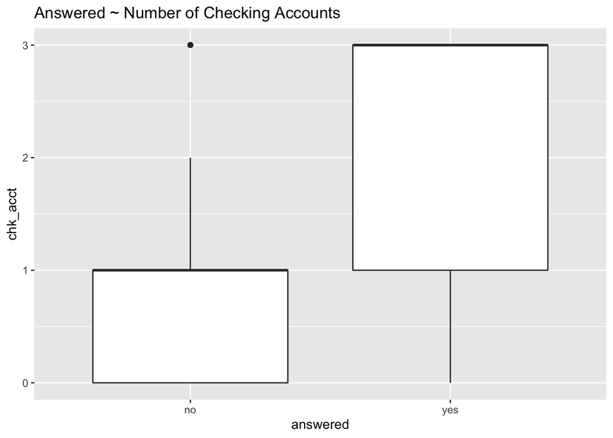

```r
# Question 4

# Turn answered var into factor
df_clean <- df_clean %>%
  mutate(answered=factor(answered))

# Rename factor levels for clarity
df_clean <- df_clean %>%
  mutate(answered=recode_factor(answered, '0'="no", '1'="yes"))

# Plot answered agaisnt number of checking accounts
ggplot(df_clean, aes(answered, chk_acct)) +
  geom_boxplot() +
  ggtitle("Answered ~ Number of Checking Accounts")
```

## Question 5

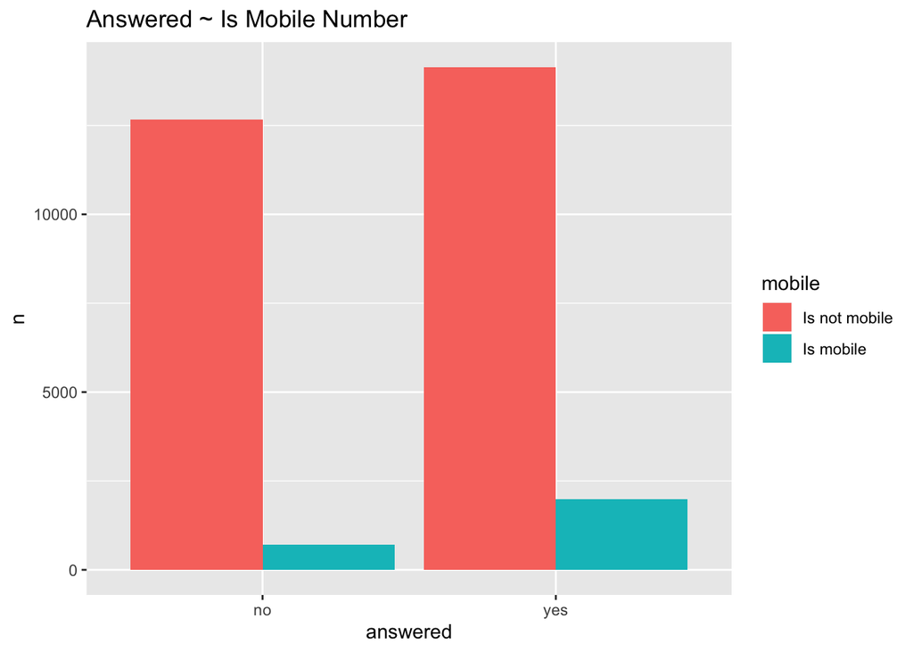

```r
# change mobile to factor and rename levels
df_clean <- df_clean %>%
  mutate(mobile=factor(mobile))  %>%
  mutate(mobile = recode_factor(mobile, '0'="Is not mobile", '1'="Is mobile"))

# plot proportions of answered and mobile binary variables
df_clean %>%
  count(answered, mobile) %>%
  ggplot(aes(answered, n, fill=mobile)) +
  geom_col(position = "dodge") +
  ggtitle("Answered ~ Is Mobile Number")
```

It looks like a lot more people do not have a mobile than do for a callback number. Given a person has a mobile call back number, they are 3x more likely to answer — 74% (1983) versus 26% (704). Given people who do not have a mobile, the outcome is less interesting, with not answering and answering being quite close - 47% and 53% respectively. While this could be interesting variable to consider, less than 10% of people (9.1%) in our sample population have a mobile. We cannot rely on this variable alone.